# Divide and Conquer - Classification using Decision Trees and Rules

Kevin D’Elia

May 13th, 2017

# 1 Overview

This notebook covers decision trees and rule learners - two machine learning methods that also make complex decisions from sets of simple choices. These methods then present their knowledge in the form of logical structures that can be understood with no statistical knowledge. This aspect makes these models particularly useful for business strategy and process improvement.

# 2 Understanding decision trees

Decision tree learners are powerful classifiers, which utilize a **tree structure** to model the relationships among the features and the potential outcomes.A decision tree classifier uses a structure of branching decisions, which channel examples into a final predicted class value.

Consider a job offer. The offer itself is the **root node**, and the offer is then passed through **decision nodes** that require choices to be made based on the attributes of the job. These choices split the data across **branches** that indicate potential outcomes of a decision, depicted as *yes* or *no* outcomes, though in some cases there may be more than two possibilities. In the case where a final decision can be made, the tree is terminated by **leaf nodes**, also known as **terminal nodes** that denote the action to be taken as the result of the series of decisions. In the case of a predictive model, the leaf nodes provide the expected result given the series of events in the tree.

A great benefit of decision tree algorithms is that the flowchart-like tree structure is not necessarily exclusively for the learner’s internal use. After the model is created, many decision tree algorithms output the resulting structure in a human-readable format. This provides tremendous insight into how and why the model works or doesn’t work well for a particular task. This also makes decision trees particularly appropriate for applications in which the classification mechanism needs to be transparent for legal reasons, or in case the results need to be shared with others in order to inform future business practices. Uses include:

- Credit scoring models in which the criteria that causes an applicant to be rejected need to be clearly documented and free from bias
- Marketing studies of customer behavior such as satisfaction or churn, which will be shared with management or advertising agencies
- Diagnosis of medical conditions based on laboratory measurements, symptoms, or the rate of disease progression

Decision trees are perhaps the single most widely used machine learning technique but are not well suited for scenarios where the data has a large number of nominal features with many levels or it has a large number of numeric features. These cases may result in a very large number of decisions and an overly complex tree.

## 2.1 Divide and Conquer

Decision trees are built using a heuristic called **recursive partitioning**. This approach is also commonly known as **divide and conquer** because it splits the data into subsets, which are then split repeatedly into ever smaller subsets, until the algorithm determines the data within the subsets are sufficiently homogeneous, or another stopping criterion has been met. The initial split criteria is the feature most predictive of the target class. The examples are then partitioned into groups according to the distinct values of this feature. Splitting continues in this way until a stopping criterion is reached, such as:

- all (or nearly all) of the examples at the node have the same class
- there are no remaining features to distinguish among the examples
- the tree has grown to a predefined size limit

# 3 The C5.0 decision tree algorithm

This is the industry standard to produce decision trees, because it does well for most types of problems directly out of the box. It can have trouble modeling some relationships due to reliance on **axis-parallel splits**.

## 3.1 Choosing the best split

The first challenge that a decision tree will face is to identify which feature to split upon, usually resulting in partitions consisting primarily of a single class. The degree to which a subset of examples contains only a single class is known as **purity**, and any subset composed of only a single class is called **pure**.

There are various measurements of purity that can be used to identify the best decision tree splitting candidate. C5.0 uses **entropy**, a concept borrowed from information theory that quantifies the randomness, or disorder, within a set of class values. Sets with high entropy are very diverse and provide little information about other items that may also belong in the set, as there is no apparent commonality. The decision tree hopes to find splits that reduce entropy, ultimately increasing homogeneity within the groups.

Typically, entropy is measured in **bits**. If there are only two possible classes, entropy values can range from 0 to 1. For *n* classes, entropy ranges from 0 to *log<sub>2</sub>(n)*. In each case, the minimum value indicates that the sample is completely homogeneous, while the maximum value indicates that the data are as diverse as possible, and no group has even a small plurality.

The mathematical representation for entropy is:

**Entropy(*S*)** = $\sum_{i=1}^{c}$ *-p<sub>i</sub> log<sub>2</sub>(p<sub>i</sub>)*

In this formula, for a given segment of data *(S)*, the term *c* refers to the number of class levels and *p<sub>i</sub>* refers to the proportion of values falling into class level *i*. For example, given a partition of data with two classes: red (60%) and white (40%), entropy is calculated as follows:

```r
-0.60 * log2(0.60) - 0.40 * log2(0.40)
```

```
## [1] 0.9709506
```

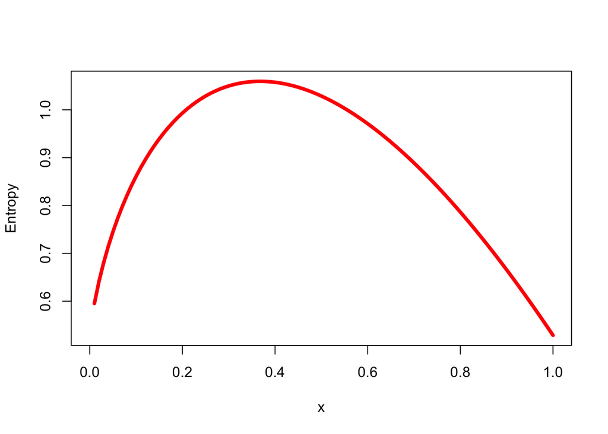

```r
x <- 0.60
xx <- 1 - x
curve(-x * log2(x) - xx * log2(xx), col = "red", xlab = "x", ylab = "Entropy", lwd = 4)
```

To use entropy to determine the optimal feature to split upon, the algorithm calculates the change in homogeneity that would result from a split on each possible feature, which is a measure know as **information gain**. The information gain for a feature *F* is calculated as the difference between the entropy in the segment before the split *(S<sub>1</sub>)* and the partitions resulting from the split *(S<sub>2</sub>)*:

**InfoGain(*F*)** = Entropy(*S<sub>1</sub>*) - Entropy(*S<sub>2</sub>*)

One complication is that after a split, the data is divided into more than one partition. Therefore, the function to calculate *Entropy(S<sub>2</sub>)* needs to consider the total entropy across all of the partitions. It does this by weighing each partitions’ entropy by the proportion of records falling into the partition. Formulaically, this is:

**Entropy(*S*)** = $\sum_{i=1}^{n}$ *w<sub>i</sub>* Entropy(*P<sub>i</sub>*)

In simple terms, the total entropy resulting from a split is the sum of the entropy of each of the *n* partitions weighted by the proportion of examples falling in the partition (*w<sub>i</sub>*).

The higher the information gain, the better a feature is at creating homogeneous groups after a split on this feature If the information gain is zero, there is no reduction in entropy for splitting on this feature. On the other hand, the maximum information gain is equal to the entropy prior to the split. This would imply that the entropy after the split is zero, which means that the split results in completely homogeneous groups.

The previous formulae assume nominal features, but decision trees use information gain for splitting on numeric features as well. To do so, a common practice is to test various splits that divide the values into groups greater than or less than a numeric threshold. This reduces the numeric feature into a two-level categorical feature that allows information gain to be calculated as usual. The numeric cut point yielding the largest information gain is chosen for the split.

## 3.2 Pruning the decision tree

A decision tree can continue to grow indefinitely, choosing splitting features and dividing the data into smaller and smaller partitions until each example is perfectly classified or the algorithm runs out of features to split on. However, if the tree grows overly large, many of the decisions it makes will be overly specific and the model will be overfitted to the training data. The process of **pruning** a decision tree involves reducing its size such that it generalizes better to unseen data.

One solution to this problem is to stop the tree from growing once it reaches a certain number of decisions or when the decision nodes contain only a small number of examples. This is called **early stopping** or **pre-pruning** the decision tree. As the tree avoids doing needless work, this is an appealing strategy. However, one downside to this approach is that there is no way to know whether the tree will miss subtle, but important patterns that it would have learned had it grown to a larger size.

An alternative, called **post-pruning**, involves growing a tree that is intentionally too large and pruning leaf nodes to reduce the size of the tree to a more appropriate level. This is often a more effective approach than pre-pruning, because it is quite difficult to determine the optimal depth of a decision tree without growing it first. Pruning the tree later on allow the algorithm to be certain that all the important data structures were discovered.

C5.0 has an overall strategy of post-pruning. Nodes and branches that have little effect on the classification errors are removed from the very large tree. In some cases, entire branches are moved further up the tree or replaced by simpler decisions. These processes of grafting branches are known as **subtree raising** and **subtree replacement**, respectively.

# 4 Example - identifying risky bank loans using C5.0 decision trees

Decision trees are widely used in the banking industry due to their high accuracy and ability to formulate a statistical model in plain language. Since government organizations in many countries carefully monitor lending practices, executives must be able to explain why one applicant was rejected for a loan while the others were approved. This information is also useful for customers hoping to determine why their credit rating is unsatisfactory.

## 4.1 Step 1 - collecting data

The idea being the credit model is to identify factors that are predictive of higher risk of default. Therefore, the data needs to contain a large number of past bank loans and whether the loan went into default, as well as information on the applicant.

The credit dataset used includes 1,000 examples on loans, plus a set of numeric and nominal features indicating the characteristics of the loan and the loan applicant. A class variable indicates whether the loan went into default.

## 4.2 Step 2 - exploring the data

Since the majority of features are already nominal in nature, the `stringsAsFactors` value will be left to its default value of `TRUE`

```r
credit <- read.csv("credit.csv")
str(credit)
```

```
## 'data.frame':    1000 obs. of  17 variables:
##  $ checking_balance    : Factor w/ 4 levels "< 0 DM","> 200 DM",..: 1 3 4 1 1 4 4 3 4 3 ...
##  $ months_loan_duration: int  6 48 12 42 24 36 24 36 12 30 ...
##  $ credit_history      : Factor w/ 5 levels "critical","good",..: 1 2 1 2 4 2 2 2 2 1 ...
##  $ purpose             : Factor w/ 6 levels "business","car",..: 5 5 4 5 2 4 5 2 5 2 ...
##  $ amount              : int  1169 5951 2096 7882 4870 9055 2835 6948 3059 5234 ...
##  $ savings_balance     : Factor w/ 5 levels "< 100 DM","> 1000 DM",..: 5 1 1 1 1 5 4 1 2 1 ...
##  $ employment_duration : Factor w/ 5 levels "< 1 year","> 7 years",..: 2 3 4 4 3 3 2 3 4 5 ...
##  $ percent_of_income   : int  4 2 2 2 3 2 3 2 2 4 ...
##  $ years_at_residence  : int  4 2 3 4 4 4 4 2 4 2 ...
##  $ age                 : int  67 22 49 45 53 35 53 35 61 28 ...
##  $ other_credit        : Factor w/ 3 levels "bank","none",..: 2 2 2 2 2 2 2 2 2 2 ...
##  $ housing             : Factor w/ 3 levels "other","own",..: 2 2 2 1 1 1 2 3 2 2 ...
##  $ existing_loans_count: int  2 1 1 1 2 1 1 1 1 2 ...
##  $ job                 : Factor w/ 4 levels "management","skilled",..: 2 2 4 2 2 4 2 1 4 1 ...
##  $ dependents          : int  1 1 2 2 2 2 1 1 1 1 ...
##  $ phone               : Factor w/ 2 levels "no","yes": 2 1 1 1 1 2 1 2 1 1 ...
##  $ default             : Factor w/ 2 levels "no","yes": 1 2 1 1 2 1 1 1 1 2 ...
```

The *table()* output shows a couple of loan features that seem likely to predict a default:

```r
table(credit$checking_balance)
```

```
##
##     < 0 DM   > 200 DM 1 - 200 DM    unknown
##        274         63        269        394
```

```r
table(credit$savings_balance)
```

```
##
##      < 100 DM     > 1000 DM  100 - 500 DM 500 - 1000 DM       unknown
##           603            48           103            63           183
```

The checking and savings account balance may prove to be important predictors of loan default status. Some of the loan’s features are numeric, such as its duration and the amount of credit requested:

```r
summary(credit$months_loan_duration)
```

```
##    Min. 1st Qu.  Median    Mean 3rd Qu.    Max.
##     4.0    12.0    18.0    20.9    24.0    72.0
```

```r
summary(credit$amount)
```

```
##    Min. 1st Qu.  Median    Mean 3rd Qu.    Max.
##     250    1366    2320    3271    3972   18424
```

The `default` vector indicates whether the loan applicant was unable to meet the agreed payment terms and went into default. A total of 30% of the loans in this dataset went into default:

```r
table(credit$default)
```

```
##
##  no yes
## 700 300
```

A high rate of default is undesirable for a bank, because it means that the bank is unlikely to fully recover its investment. If the model is successful, it will identify applicants that are at high risk to default, allowing the bank to refuse credit requests.

### 4.2.1 Data preparation - creating random training and test datasets

To create the training and test datasets, it is necessary to consider if the data in question is ordered or unordered. In this case, there is a strong likelihood that the credit data might be sorted by loan amount, so if the training data was 90% and the testing data the remaining 10%, the model will be developed on a biased set of data. This can by solved by using a **random sample**; reproducibility is achieved by using a **seed** value:

```r
set.seed(123)
train_sample <- sample(1000, 900)
credit_train <- credit[train_sample, ]
credit_test <- credit[-train_sample, ]
```

This code should result in roughly the same results for defaulted loans that was available in the full dataset:

```r
round(prop.table(table(credit_train$default)), 2)
```

```
##
##  no yes
## 0.7 0.3
```

```r
round(prop.table(table(credit_test$default)), 1)
```

```
##
##  no yes
## 0.7 0.3
```

## 4.3 Step 3 - training a model on the data

**Building the classifier:**

`m <- C5.0(train, class, trials, = 1, costs = NULL)`

- *train* is a data frame containing training data
- *class* is a factor vector with the class for each row in the training data
- *trials* is an optional number to control the number of boosting iterations (set to 1 by default)
- *costs* is an optional matrix specifying costs associated with various types.

The function will return a C5.0 model object that can be used to make predictions.

**Making predictions:**

`p <- predict(m, test, type = "class")`

- *m* is a model trained by the C5.0 function
- *test* is a data frame containing test data with the same features as the training data used to build the classifier
- *type* is either “class” or “prob” and specifies whether the predictions should be the most probable class or the raw predicted probabilities

The function will return a vector of predicted class values or raw predicted probabilities depending upon the value of the **type** parameter.

Since the *default* class variable is to be predicted, it must be excluded from the training data frame but supplied as the target factor vector for classification:

```r
library(C50)
credit_model <- C5.0(credit_train[-17], credit_train$default)
credit_model
```

```
##
## Call:
## C5.0.default(x = credit_train[-17], y = credit_train$default)
##
## Classification Tree
## Number of samples: 900
## Number of predictors: 16
##
## Tree size: 57
##
## Non-standard options: attempt to group attributes
```

The output shows some simple facts about the tree, including the function call that generated it, the number of features (labeled *predictors*), and examples (labeled *samples*) used to grow the tree. The tree size indicates the decision depth of the tree. The *summary()* function shows the tree’s decisions:

```r
summary(credit_model)
```

```
##
## Call:
## C5.0.default(x = credit_train[-17], y = credit_train$default)
##
##
## C5.0 [Release 2.07 GPL Edition]      Tue May 30 15:14:36 2017
## -------------------------------
##
## Class specified by attribute `outcome'
##
## Read 900 cases (17 attributes) from undefined.data
##
## Decision tree:
##
## checking_balance in {> 200 DM,unknown}: no (412/50)
## checking_balance in {< 0 DM,1 - 200 DM}:
## :...credit_history in {perfect,very good}: yes (59/18)
##     credit_history in {critical,good,poor}:
##     :...months_loan_duration <= 22:
##         :...credit_history = critical: no (72/14)
##         :   credit_history = poor:
##         :   :...dependents > 1: no (5)
##         :   :   dependents <= 1:
##         :   :   :...years_at_residence <= 3: yes (4/1)
##         :   :       years_at_residence > 3: no (5/1)
##         :   credit_history = good:
##         :   :...savings_balance in {> 1000 DM,500 - 1000 DM}: no (15/1)
##         :       savings_balance = 100 - 500 DM:
##         :       :...other_credit = bank: yes (3)
##         :       :   other_credit in {none,store}: no (9/2)
##         :       savings_balance = unknown:
##         :       :...other_credit = bank: yes (1)
##         :       :   other_credit in {none,store}: no (21/8)
##         :       savings_balance = < 100 DM:
##         :       :...purpose in {business,car0,renovations}: no (8/2)
##         :           purpose = education:
##         :           :...checking_balance = < 0 DM: yes (4)
##         :           :   checking_balance = 1 - 200 DM: no (1)
##         :           purpose = car:
##         :           :...employment_duration = > 7 years: yes (5)
```

[output cut: 94 more lines]

```
##   54.22% credit_history
##   47.67% months_loan_duration
##   38.11% savings_balance
##   14.33% purpose
##   14.33% housing
##   12.56% employment_duration
##    9.00% job
##    8.67% other_credit
##    6.33% years_at_residence
##    2.22% percent_of_income
##    1.56% dependents
##    0.56% amount
##
##
## Time: 0.0 secs
```

The summary output shows some of the first branches in the decision tree. The first three lines could be represented in plain language as:

1. If the checking account balance is unknown or greater than 200 DM, then classify as “not likely to default.”
2. Otherwise, if the checking account balance is lees than 0 DM or between 1 and 200 DM.
3. And the credit history is perfect or very good, then classify as “likely to default.”

The numbers in parentheses indicate the number of examples meeting the criteria for that decision, and the number incorrectly classified by the decision. For instance, on the first line, 412/50 indicates that of the 412 examples reaching the decision, 50 were incorrectly classified as not likely to default. In other words, 50 applicants actually defaulted in spite of the model’s prediction to the contrary.

After the tree, the `summary(credit_model)` output displays a confusion matrix, which is a cross-tabulation that indicates the model’s incorrectly classified records in the training data. The *Errors* output notes that the model correctly classified all but 133 of the 900 training instances for an error rate of 14.8%. A total of 35 actual *no* values were incorrectly classified as *ues* (false positives), while 98 *yes* values were misclassified as *no* (false negatives).

## 4.4 Step 4 - evaluating model performance

Use the *predict()* function now on the test dataset:

```r
credit_pred <- predict(credit_model, credit_test)
```

This creates a vector pf predicted class values, which can be compared to the actual class values using the *CrossTable()* function; the row and column percentages have been suppressed:

```r
library(gmodels)
CrossTable(credit_test$default,
           credit_pred,
           prop.chisq = FALSE,
           prop.c = FALSE,
           prop.r = FALSE,
           dnn = c('actual default', 'predicted default'))
```

```
##
##
##    Cell Contents
## |-------------------------|
## |                       N |
## |         N / Table Total |
## |-------------------------|
##
##
## Total Observations in Table:  100
##
##
##                | predicted default
## actual default |        no |       yes | Row Total |
## ---------------|-----------|-----------|-----------|
##             no |        59 |         8 |        67 |
##                |     0.590 |     0.080 |           |
## ---------------|-----------|-----------|-----------|
##            yes |        19 |        14 |        33 |
##                |     0.190 |     0.140 |           |
## ---------------|-----------|-----------|-----------|
##   Column Total |        78 |        22 |       100 |
## ---------------|-----------|-----------|-----------|
##
##
```

## 4.5 Step 5 - improving model performance

The model’s error rate is likely to be too high to deploy it in a real-time credit scoring application. In fact, if the model had predicted “no default” for every test case, it would have been correct 67% of the time - a result not much worse than the model’s but requiring much less effort. Making matters even worse, the model performed especially poorly at identifying applicants who do default on their loans.

### 4.5.1 Boosting the accuracy of decision trees

Using **adaptive boosting**, a process in which many decision trees are built and the trees vote on the best class for each example, the model can be improved. Boosting is rooted in the notion that by combining a number of weak performing learners, a team that is much stronger than any of the learners alone can be created. Each of the models has a unique set of strengths and weaknesses and they may be better or worse in solving certain problems. Using a combination of several learners with complementary strengths and weaknesses can therefore dramatically improve the accuracy of a classifier.

By adding an additional `trials` parameter indicating the number of separate decision trees to use in the boosted team and setting an upper limit, the algorithm will stop adding trees if it recognizes that additional trials do not seem to be improving the accuracy.

```r
credit_boost10 <- C5.0(credit_train[-17],
                       credit_train$default,
                       trials = 10)
```

While examining the resulting model, some additional lines have been added, indicating the changes:

```r
credit_boost10
```

```
##
## Call:
## C5.0.default(x = credit_train[-17], y = credit_train$default, trials = 10)
##
## Classification Tree
## Number of samples: 900
## Number of predictors: 16
##
## Number of boosting iterations: 10
## Average tree size: 47.5
##
## Non-standard options: attempt to group attributes
```

So the tree size has shrunk. All 10 trees, along with the model’s performance, can be summarized:

```r
summary(credit_boost10)
```

```
##
## Call:
## C5.0.default(x = credit_train[-17], y = credit_train$default, trials = 10)
##
##
## C5.0 [Release 2.07 GPL Edition]      Tue May 30 15:14:36 2017
## -------------------------------
##
## Class specified by attribute `outcome'
##
## Read 900 cases (17 attributes) from undefined.data
##
## -----  Trial 0:  -----
##
## Decision tree:
##
## checking_balance in {> 200 DM,unknown}: no (412/50)
## checking_balance in {< 0 DM,1 - 200 DM}:
## :...credit_history in {perfect,very good}: yes (59/18)
##     credit_history in {critical,good,poor}:
##     :...months_loan_duration <= 22:
##         :...credit_history = critical: no (72/14)
##         :   credit_history = poor:
##         :   :...dependents > 1: no (5)
##         :   :   dependents <= 1:
##         :   :   :...years_at_residence <= 3: yes (4/1)
##         :   :       years_at_residence > 3: no (5/1)
##         :   credit_history = good:
##         :   :...savings_balance in {> 1000 DM,500 - 1000 DM}: no (15/1)
##         :       savings_balance = 100 - 500 DM:
##         :       :...other_credit = bank: yes (3)
##         :       :   other_credit in {none,store}: no (9/2)
##         :       savings_balance = unknown:
##         :       :...other_credit = bank: yes (1)
##         :       :   other_credit in {none,store}: no (21/8)
##         :       savings_balance = < 100 DM:
##         :       :...purpose in {business,car0,renovations}: no (8/2)
##         :           purpose = education:
##         :           :...checking_balance = < 0 DM: yes (4)
##         :           :   checking_balance = 1 - 200 DM: no (1)
```

[output cut: 952 more lines]

```
##   94.78% credit_history
##   94.67% other_credit
##   92.56% job
##   92.11% percent_of_income
##   90.33% amount
##   85.11% months_loan_duration
##   82.78% age
##   82.78% existing_loans_count
##   75.78% dependents
##   71.56% housing
##   70.78% savings_balance
##   49.22% phone
##
##
## Time: 0.0 secs
```

```r
credit_boost_pred10 <- predict(credit_boost10, credit_test)
CrossTable(credit_test$default,
           credit_boost_pred10,
           prop.chisq = FALSE,
           prop.c = FALSE,
           prop.r = FALSE,
           dnn = c("actual default", "predicted default"))
```

```
##
##
##    Cell Contents
## |-------------------------|
## |                       N |
## |         N / Table Total |
## |-------------------------|
##
##
## Total Observations in Table:  100
##
##
##                | predicted default
## actual default |        no |       yes | Row Total |
## ---------------|-----------|-----------|-----------|
##             no |        62 |         5 |        67 |
##                |     0.620 |     0.050 |           |
## ---------------|-----------|-----------|-----------|
##            yes |        13 |        20 |        33 |
##                |     0.130 |     0.200 |           |
## ---------------|-----------|-----------|-----------|
##   Column Total |        75 |        25 |       100 |
## ---------------|-----------|-----------|-----------|
##
##
```

The total error rate was reduced from 27% prior to boosting down to 18% in the boosted model but the model is still not doing well at predicting defaults, predicting only 20/33 = 61% correctly. The lack of an even greater improvement may be a function of the relatively small training dataset or it may just be a very difficult problem to solve.

This said, if boosting can be added this easily, why not apply it all the time? Two reasons:

1. building one decision tree can be computationally expensive and building many trees may be impractical
2. if the training data is very noisy, then boosting might not result in an improvement at all

### 4.5.2 Making mistakes more costlier than others

Giving a loan out to an applicant who is likely to default can be an expensive mistake. One solution to reduce the number of false negatives may be to reject a larger number of borderline applicant, under the assumption that the interest the bank would earn from a risky loan is far outweighed by the massive loss it would incur if the money is not paid back at all.

The C5.0 algorithm allows the assignment of a penalty to different types of errors, in order to discourage a tree from making more costly mistakes. The penalties are designated in a **cost matrix**, which specifies how much costlier each error is, relative to any other prediction.

To begin constructing the cost matrix, start by specifying the dimensions. Since the predicted and actual values can both take two values, *yes* or *no*, a 2x2 matrix is needed, using a list of two vectors, each with two values. Giving names to the matrix dimensions will avoid later confusion.

```r
matrix_dimensions <- list(c("no", "yes"), c("no", "yes"))
names(matrix_dimensions) <- c("predicted", "actual")
```

Next, assign the penalty for the various types of errors by supplying four values to fill the matrix, like so:

- Predicted no, actual no
- Predicted yes, actual no
- Predicted no, actual yes
- Predicted yes, actual yes

Suppose the theory is that a loan default costs the bank four times as much as a missed opportunity. The penalty values would then be defined as:

```r
error_cost <- matrix(c(0, 1, 4, 0), nrow = 2, dimnames = matrix_dimensions)
```

As defined by this matrix, there is no cost assigned when the algorithm classifies a *no* or *yes* correctly, but a false negative has a cost of 4 versus a false positive’s cost of 1. Apply this now to the existing data:

```r
# apply the cost matrix to the tree
credit_cost <- C5.0(credit_train[-17],
                    credit_train$default,
                    costs = error_cost)

credit_cost_pred <- predict(credit_cost, credit_test)

CrossTable(credit_test$default,
           credit_cost_pred,
           prop.chisq = FALSE,
           prop.c = FALSE,
           prop.r = FALSE,
           dnn = c('actual default', 'predicted default'))
```

```
##
##
##    Cell Contents
## |-------------------------|
## |                       N |
## |         N / Table Total |
## |-------------------------|
##
##
## Total Observations in Table:  100
##
##
##                | predicted default
## actual default |        no |       yes | Row Total |
## ---------------|-----------|-----------|-----------|
##             no |        37 |        30 |        67 |
##                |     0.370 |     0.300 |           |
## ---------------|-----------|-----------|-----------|
##            yes |         7 |        26 |        33 |
##                |     0.070 |     0.260 |           |
## ---------------|-----------|-----------|-----------|
##   Column Total |        44 |        56 |       100 |
## ---------------|-----------|-----------|-----------|
##
##
```

# 5 Understanding classification rules

Classification rules represent knowledge in the form of logical if-else statements that assign a class to unlabeled examples. They are specified in terms of an **antecedent** and a **consequent**; these form a hypothesis stating that “if this happens, then that happens.”, such as a hard drive clicking means that it will fail soon. The antecedent comprises certain combinations of feature values, while the consequent specifies the class value to assign when the rule’s conditions are met.

Rule learners are often used in a manner similar to decision tree learners. Like decision trees, they can be used for applications that generate knowledge for future action, such as:

- Identifying conditions that lead to a hardware failure in mechanical devices
- Describing the key characteristics of groups of people for customer segmentation
- Finding conditions that precede large drops or increases in the prices of shares on the stock market

On the other hand, rule learners offer some distinct advantages over trees for some tasks. Unlike a tree, which must be applied from top-to-bottom through a series of decisions, rules are propositions that can be read much like a statement of fact. Additionally, the results of a rule learner can be more simple, direct, and easier to understand than a decision tree built on the same data.

Rule learners are generally applied to problems where the features are primarily or entirely nominal. They do well at identifying rare events, even if the rare event occurs only for a very specific interaction among feature values.

# 6 Separate and conquer

Classification rule learning algorithms utilize a heuristic known as **separate and conquer**. The process involves identifying a rule that covers a subset of examples in the training data, and then separating this partition from the remaining data. As the rules are added, additional subsets of the data are separated until the entire dataset has been covered and no more examples remain.

One way to imagine the rule learning process is to think about drilling down into the data by creating increasingly specific rules to identify class values. To identify whether or not an animal is a mammal, the set of all animals can be depicted as a large space. A rule learner begins by using the available features to find homogeneous groups. For example, using a feature that indicates whether the species travels via land, sea, or air. the first rule might suggest that any land-based animals are mammals. But the rule might include animals like frogs, which are not mammals. A more specific rule would state that mammals must walk on land and have a tail. An additional rule might require that to be classified as a mammal, the animal must have fur. And so on. This shows how rules gradually consume larger and larger segments of data to eventually classify all instances.

As the rules seem to cover portions of the data, separate and conquer algorithms are also known as **covering algorithms**, and the resulting rules are called **covering rules**.

# 7 The 1R Algorithm

The simplest classifier, **ZeroR**, is a rule learner that literally learns no rules (hence the name). For every unlabeled example, regardless of the values of its features, it predicts the most common class.

The **1R algorithm** (**One Rule** or **OneR**) improves over ZeroR by selecting a single rule. The way this algorithm works is simple. For each feature, 1R divides the data into groups based on similar values of the feature. Then, for each segment, the algorithm predicts the majority class. The error rate for the rule based on each feature is calculated and the rule with the fewest errors is chosen as the one rule. Obviously, this rule learning algorithm may be too basic for some tasks, such as considering only a single symptom in a medical diagnosis system.

# 8 The RIPPER algorithm

Early rule learning algorithms were plagued by a couple of problems. First, they were notorious for being slow, which made them ineffective for the increasing number of large datasets. Secondly, they were often prone to being inaccurate on noisy data.

A first step was the **Incremental Reduced Error Pruning (IREP) algorithm** which uses a combination of pre-pruning and post-pruning methods that grow very complex rules and prune them before separating the instances from the full dataset. Although this strategy helped the performance of rule learners, decision trees often still performed better.

The **Repeated Incremental Pruning to Produce Error Reduction (RIPPER) algorithm** improved upon IREP to generate rules that match or exceed the performance of decision trees. Having evolved from several iterations of rule learning algorithms, the RIPPER algorithm is a patchwork of efficient heuristics for rule learning. It can be understood in general terms as a three-step process:

1. Grow
2. Prune
3. Optimize

The growing phase uses the separate and conquer technique to greedily add conditions to a rule until it perfectly classifies a subset of data or runs out of attributes for splitting. Similar to decision trees, the information gain criterion is used to identify the next splitting attribute. When increasing a rule’s specificity no longer reduces entropy, the rule is immediately pruned. Steps one and two are repeated until it reaches a stopping criterion, at which point the entire set of rules is optimized using a variety of heuristics.

# 9 Rules from decision trees

Classification rules can also be obtained directly from decision trees. Beginning at a leaf node and following the branches back to the root results in a series of decisions. These can be combined into a single rule. The chief downside to using a decision tree to generate rules is that the resulting rules are often more complex than those learned by a rule learning algorithm. The divide and conquer strategy employed by decision trees biases the results differently than that of a rule learner. On the other hand, it is sometimes more computationally efficient to generate rules from trees. The `C5.0` function will generate a model using classification rules if you specify `rules = TRUE` when training the model.

# 10 What makes trees and rules greedy?

Decision trees and rule learners are known as **greedy learners** because they use data on a first-come, first-served basis. Both the divide and conquer heuristic used by decision trees and the separate and conquer heuristic used by rule learners attempt to make partitions one at at time, finding the most homogeneous partition first. followed by the next best, and so on, until all examples have been classified.

The downside to the greedy approach is that greedy algorithms are not guaranteed to generate the optimal, most accurate, or smallest number of rules for a particular dataset. By taking the low-hanging fruit early, a greedy learner may quickly find a single rule that is accurate for one subset of data; however, in doing so, the learner may miss the opportunity to develop a more nuanced set of rules with better overall accuracy on the entire set of data. However, without using the greedy approach to rule learning, it is likely that for all but the smallest of datasets, rule learning would be computationally infeasible.

Though both trees and rules employ greedy learning heuristics, there are subtle differences in how they build rules. Perhaps the best way to distinguish them is to note that once divide and conquer splits on a feature, the partitions created by the split may not be re-conquered, only further subdivided. In this way, a tree is permanently limited by its history of past decisions. In contrast, once separate and conquer finds a rule, any examples not covered by all of the rule’s conditions may be re-conquered.

# 11 Example - identifying poisonouse mushrooms with rule learners

Unlike the identification of harmful plants such as poison oak or poison ivy, there are no clear rules to identify whether a wild mushroom is poisonous or edible. If simple, clear, and consistent rules were available to identify poisonous mushrooms, they could save the lives of foragers.

## 11.1 Step 1 - collecting the data

The dataset used includes information on 8,124 mushroom samples from 23 species of gilled mushrooms and consists of two classes: poisonous and non-poisonous.

## 11.2 Step 2 - exploring and preparing the data

Since all the 22 features and the target class are nominal, use `stringsAsFactors` equal to **TRUE**.

```r
mushrooms <- read.csv("mushrooms.csv", stringsAsFactors = TRUE)
```

```r
str(mushrooms)
```

```
## 'data.frame':    8124 obs. of  23 variables:
##  $ type                    : Factor w/ 2 levels "edible","poisonous": 2 1 1 2 1 1 1 1 2 1 ...
##  $ cap_shape               : Factor w/ 6 levels "bell","conical",..: 3 3 1 3 3 3 1 1 3 1 ...
##  $ cap_surface             : Factor w/ 4 levels "fibrous","grooves",..: 4 4 4 3 4 3 4 3 3 4 ...
##  $ cap_color               : Factor w/ 10 levels "brown","buff",..: 1 10 9 9 4 10 9 9 9 10 ...
##  $ bruises                 : Factor w/ 2 levels "no","yes": 2 2 2 2 1 2 2 2 2 2 ...
##  $ odor                    : Factor w/ 9 levels "almond","anise",..: 8 1 2 8 7 1 1 2 8 1 ...
##  $ gill_attachment         : Factor w/ 2 levels "attached","free": 2 2 2 2 2 2 2 2 2 2 ...
##  $ gill_spacing            : Factor w/ 2 levels "close","crowded": 1 1 1 1 2 1 1 1 1 1 ...
##  $ gill_size               : Factor w/ 2 levels "broad","narrow": 2 1 1 2 1 1 1 1 2 1 ...
##  $ gill_color              : Factor w/ 12 levels "black","brown",..: 1 1 2 2 1 2 5 2 8 5 ...
##  $ stalk_shape             : Factor w/ 2 levels "enlarging","tapering": 1 1 1 1 2 1 1 1 1 1 ...
##  $ stalk_root              : Factor w/ 5 levels "bulbous","club",..: 3 2 2 3 3 2 2 2 3 2 ...
##  $ stalk_surface_above_ring: Factor w/ 4 levels "fibrous","scaly",..: 4 4 4 4 4 4 4 4 4 4 ...
##  $ stalk_surface_below_ring: Factor w/ 4 levels "fibrous","scaly",..: 4 4 4 4 4 4 4 4 4 4 ...
##  $ stalk_color_above_ring  : Factor w/ 9 levels "brown","buff",..: 8 8 8 8 8 8 8 8 8 8 ...
##  $ stalk_color_below_ring  : Factor w/ 9 levels "brown","buff",..: 8 8 8 8 8 8 8 8 8 8 ...
##  $ veil_type               : Factor w/ 1 level "partial": 1 1 1 1 1 1 1 1 1 1 ...
##  $ veil_color              : Factor w/ 4 levels "brown","orange",..: 3 3 3 3 3 3 3 3 3 3 ...
##  $ ring_number             : Factor w/ 3 levels "none","one","two": 2 2 2 2 2 2 2 2 2 2 ...
##  $ ring_type               : Factor w/ 5 levels "evanescent","flaring",..: 5 5 5 5 1 5 5 5 5 5 ...
##  $ spore_print_color       : Factor w/ 9 levels "black","brown",..: 1 2 2 1 2 1 1 2 1 1 ...
##  $ population              : Factor w/ 6 levels "abundant","clustered",..: 4 3 3 4 1 3 3 4 5 4 ...
##  $ habitat                 : Factor w/ 7 levels "grasses","leaves",..: 5 1 3 5 1 1 3 3 1 3 ...
```

```r
mushrooms$veil_color <- NULL
```

Looking at the distribution of mushrooms types:

```r
table(mushrooms$type)
```

```
##
##    edible poisonous
##      4208      3916
```

shows that about 52% of the mushroom samples are edible, while 48% are poisonous.

## 11.3 Step 3 - training a model on the data

What would a hypothetical ZeroR classifier predict for this data? Since ZeroR ignores all of the features and simply predicts the target’s mode, its rule would state that all mushrooms are edible. This is not a helpful classification. Simple rules can often be extremely predictive, and the 1R classifier, which is a simple rule learner, can be used to identify the most predictive single feature of the target class and use it to construct a set of rules. The 1R implementation to be used is found in the *RWeka* package:

**Building the classifier:** `m <- OneR(class ~ predictors, data = mydata)`

where:

- *class* is the column in the **mydata** data frame to be predicted
- *predictors* is an R formula specifying the features in the **mydata** data frame to use for prediction
- *data* is the data frame in which **class** and *predictors** can be found

The function will return a 1R model object that can be used to make predictions.

**Making predictions** `p <- predict(m, test)`

where:

- *m* is a model trained by the **OneR()** function
- *test* is a data frame containing test data with the same features as the training data used to build the classifier

The function will return a vector of predicted class values.

The *OneR()* implementation uses the R formula syntax to specify the model to be trained, using the tilde to express the relationship between a target variable and its predictors. The class variable to be learned goes to the left of the tilde, and the predictor features are written on the right, separated by + operators. Example: *y ~ x1 + x2*. The special case shown next uses all the predictors to arrive at a response variable: *y ~ .*, which specifies the relationship between *y* and all the other features in the dataset.

```r
library(RWeka)
mushroom_1R <- OneR(type ~ ., data = mushrooms)
```

To examine the rules it created, type the name of the classifier object:

```r
mushroom_1R
```

```
## odor:
##  almond  -> edible
##  anise   -> edible
##  creosote    -> poisonous
##  fishy   -> poisonous
##  foul    -> poisonous
##  musty   -> poisonous
##  none    -> edible
##  pungent -> poisonous
##  spicy   -> poisonous
## (8004/8124 instances correct)
```

the first line of the output shows that the *odor* feature was selected for rule generation. The categories of odor, such as almond, anise, and so on, specify rules for whether the mushroom is likely to be edible or poisonous. If the mushroom has a fishy or foul odor, it is likely to be poisonous. On the other hand, if it smells like an almond or has no perceived smell, it is likely to be edible. These rules could be summarized by saying if it smells bad, don’t eat it!

## 11.4 Step 4 - evaluation model performance

The last line of the output notes that the rules correctly predicted the edibility of 8,004 of the 8,124 mushrooms or nearly 99% of the mushroom samples. More details are available via *summary()*:

```r
summary(mushroom_1R)
```

```
##
## === Summary ===
##
## Correctly Classified Instances        8004               98.5229 %
## Incorrectly Classified Instances       120                1.4771 %
## Kappa statistic                          0.9704
## Mean absolute error                      0.0148
## Root mean squared error                  0.1215
## Relative absolute error                  2.958  %
## Root relative squared error             24.323  %
## Total Number of Instances             8124
##
## === Confusion Matrix ===
##
##     a    b   <-- classified as
##  4208    0 |    a = edible
##   120 3796 |    b = poisonous
```

Examining the table, it is evident that while the 1R classifier did not classify any edible mushrooms as poisonous, it did classify 120 poisonous mushrooms as edible! By trying to add a few more rules, perhaps an even better classifier can be developed.

## 11.5 Step 5 - improving model performance

For a more sophisticated rule learner, the **RWeka** package includes *JRip()*, a Java-based implementation of the RIPPER rule learning algorithm.

**Building the classifier**

`m <- JRip(class ~ predictors, data = mydata)`

where:

- *class* is the column in the **mydata** data frame to be predicted
- *predictors* is an $ formula specifying the features in the **mydata** data frame to use for prediction
- *data* is the data frame in which **class** and **predictors** can be found

The function will return a RIPPER model object that can be used to make predictions.

**Making predictions:**

`p <- predict(m, test)`

where:

- *m* is a model trained by the **JRip()** function
- *test* is a data frame containing test data with the same features as the training data used to build the classifier

The function will return a vector of predicted class values.

Train the JRip() rule learner in the same way as with OneR(), allowing it to choose rules from all the available features:

```r
mushroom_JRip <- JRip(type ~ ., data = mushrooms)
mushroom_JRip
```

```
## JRIP rules:
## ===========
##
## (odor = foul) => type=poisonous (2160.0/0.0)
## (gill_size = narrow) and (gill_color = buff) => type=poisonous (1152.0/0.0)
## (gill_size = narrow) and (odor = pungent) => type=poisonous (256.0/0.0)
## (odor = creosote) => type=poisonous (192.0/0.0)
## (spore_print_color = green) => type=poisonous (72.0/0.0)
## (stalk_surface_below_ring = scaly) and (stalk_surface_above_ring = silky) => type=poisonous (68.0/0.0)
## (stalk_color_above_ring = yellow) => type=poisonous (8.0/0.0)
## (habitat = leaves) and (cap_color = white) => type=poisonous (8.0/0.0)
##  => type=edible (4208.0/0.0)
##
## Number of Rules : 9
```

An easy way to read these rules is to think of them as a list of if-else statements, similar to programming logic.